# Exam example

Anahita Esfandiaryfard

# Data

```r
winequality <-read.csv("http://archive.ics.uci.edu/ml/machine-learning-databases/wine-quality/winequality-white.csv",sep = ";")
```

# Question1

```r
str(winequality)
```

```
'data.frame':   4898 obs. of  12 variables:
 $ fixed.acidity       : num  7 6.3 8.1 7.2 7.2 8.1 6.2 7 6.3 8.1 ...
 $ volatile.acidity    : num  0.27 0.3 0.28 0.23 0.23 0.28 0.32 0.27 0.3 0.22 ...
 $ citric.acid         : num  0.36 0.34 0.4 0.32 0.32 0.4 0.16 0.36 0.34 0.43 ...
 $ residual.sugar      : num  20.7 1.6 6.9 8.5 8.5 6.9 7 20.7 1.6 1.5 ...
 $ chlorides           : num  0.045 0.049 0.05 0.058 0.058 0.05 0.045 0.045 0.049 0.044 ...
 $ free.sulfur.dioxide : num  45 14 30 47 47 30 30 45 14 28 ...
 $ total.sulfur.dioxide: num  170 132 97 186 186 97 136 170 132 129 ...
 $ density             : num  1.001 0.994 0.995 0.996 0.996 ...
 $ pH                  : num  3 3.3 3.26 3.19 3.19 3.26 3.18 3 3.3 3.22 ...
 $ sulphates           : num  0.45 0.49 0.44 0.4 0.4 0.44 0.47 0.45 0.49 0.45 ...
 $ alcohol             : num  8.8 9.5 10.1 9.9 9.9 10.1 9.6 8.8 9.5 11 ...
 $ quality             : int  6 6 6 6 6 6 6 6 6 6 ...
```

The dataframe contains 4898 data and 12 variables.We can check if there are any na value as follows,

```r
any(is.na(winequality))
```

```
[1] FALSE
```

The dataframe does not contain any na values. # Question2 The following code will add the high.quality column and transform it into a factor

```r
winequality$high.quality <- factor (as.integer(winequality$quality>6))
```

we check the number of level in high.quality as follows:

```r
levels(winequality$high.quality)
```

```
[1] "0" "1"
```

The column has two levels. Due to its definitions, the columns has two levels: 0 and 1.

# Question 3

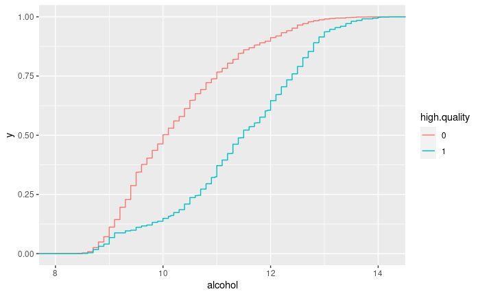

```r
library(ggplot2)
ggplot(winequality, aes(x=alcohol, color=high.quality))+stat_ecdf()
```

from the curve we can note that high wine has more alcohol.

# Question 4

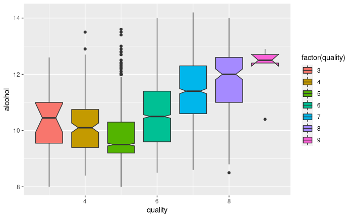

```r
ggplot(winequality, aes(x=quality, y=alcohol, fill= factor(quality))) +
  geom_boxplot(notch = T)
```

```r
c <- cor(winequality[-c(12,13)])
c
```

```
                     fixed.acidity volatile.acidity citric.acid
fixed.acidity           1.00000000      -0.02269729  0.28918070
volatile.acidity       -0.02269729       1.00000000 -0.14947181
citric.acid             0.28918070      -0.14947181  1.00000000
residual.sugar          0.08902070       0.06428606  0.09421162
chlorides               0.02308564       0.07051157  0.11436445
free.sulfur.dioxide    -0.04939586      -0.09701194  0.09407722
total.sulfur.dioxide    0.09106976       0.08926050  0.12113080
density                 0.26533101       0.02711385  0.14950257
pH                     -0.42585829      -0.03191537 -0.16374821
sulphates              -0.01714299      -0.03572815  0.06233094
alcohol                -0.12088112       0.06771794 -0.07572873
                     residual.sugar   chlorides free.sulfur.dioxide
fixed.acidity            0.08902070  0.02308564       -0.0493958591
volatile.acidity         0.06428606  0.07051157       -0.0970119393
citric.acid              0.09421162  0.11436445        0.0940772210
residual.sugar           1.00000000  0.08868454        0.2990983537
chlorides                0.08868454  1.00000000        0.1013923521
free.sulfur.dioxide      0.29909835  0.10139235        1.0000000000
total.sulfur.dioxide     0.40143931  0.19891030        0.6155009650
density                  0.83896645  0.25721132        0.2942104109
pH                      -0.19413345 -0.09043946       -0.0006177961
sulphates               -0.02666437  0.01676288        0.0592172458
alcohol                 -0.45063122 -0.36018871       -0.2501039415
                     total.sulfur.dioxide     density            pH
fixed.acidity                 0.091069756  0.26533101 -0.4258582910
volatile.acidity              0.089260504  0.02711385 -0.0319153683
citric.acid                   0.121130798  0.14950257 -0.1637482114
residual.sugar                0.401439311  0.83896645 -0.1941334540
chlorides                     0.198910300  0.25721132 -0.0904394560
free.sulfur.dioxide           0.615500965  0.29421041 -0.0006177961
total.sulfur.dioxide          1.000000000  0.52988132  0.0023209718
density                       0.529881324  1.00000000 -0.0935914935
pH                            0.002320972 -0.09359149  1.0000000000
sulphates                     0.134562367  0.07449315  0.1559514973
alcohol                      -0.448892102 -0.78013762  0.1214320987
                       sulphates     alcohol
fixed.acidity        -0.01714299 -0.12088112
volatile.acidity     -0.03572815  0.06771794
citric.acid           0.06233094 -0.07572873
residual.sugar       -0.02666437 -0.45063122
chlorides             0.01676288 -0.36018871
free.sulfur.dioxide   0.05921725 -0.25010394
total.sulfur.dioxide  0.13456237 -0.44889210
density               0.07449315 -0.78013762
pH                    0.15595150  0.12143210
sulphates             1.00000000 -0.01743277
alcohol              -0.01743277  1.00000000
```

# Question 6

To easily check what is the strongest relationship, I will use corrplot:

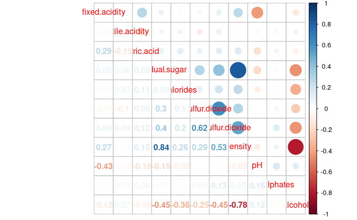

```r
library(corrplot)
corrplot.mixed(c)
```

The pair with the strongest correlation is residual.sugar-density.This is positive strong positive correlation.

```r
cor.test(winequality$density, winequality$residual.sugar)
```

```
    Pearson's product-moment correlation

data:  winequality$density and winequality$residual.sugar
t = 107.87, df = 4896, p-value < 2.2e-16
alternative hypothesis: true correlation is not equal to 0
95 percent confidence interval:
 0.8304732 0.8470698
sample estimates:
      cor
0.8389665
```

# Question 7

Let us first subset the dataset to separate low and high quality wines:

```r
high.quality.wines <- subset(winequality, high.quality==1)
low.quality.wines <- subset(winequality, high.quality==0)
```

The average amount of alcohol in high quality wines is:

```r
mean(high.quality.wines$alcohol)
```

```
[1] 11.41602
```

The average amount of alcohol in low quality wines is:

```r
mean(low.quality.wines$alcohol)
```

```
[1] 10.26522
```

It looks like high quality wines have more alcohol. Let us check that with a statistical test:

```r
t.test(high.quality.wines$alcohol, low.quality.wines$alcohol)
```

```
    Welch Two Sample t-test

data:  high.quality.wines$alcohol and low.quality.wines$alcohol
t = 27.11, df = 1537.3, p-value < 2.2e-16
alternative hypothesis: true difference in means is not equal to 0
95 percent confidence interval:
 1.067541 1.234072
sample estimates:
mean of x mean of y
 11.41602  10.26522
```

The p-value is below the significance level, so the difference between the means is actually statistically significant.

Let us fit the regressor: # Question 8

```r
(reg <- lm(density ~ residual.sugar, winequality))
```

```
Call:
lm(formula = density ~ residual.sugar, data = winequality)

Coefficients:
   (Intercept)  residual.sugar
     0.9908654       0.0004947
```

We expect a density equal to 0.99 when observing a value of residual.sugar equal to 0.

# Question 9

we will use the summary function to show the summary of the regresor:

```r
summary(reg)
```

```
Call:
lm(formula = density ~ residual.sugar, data = winequality)

Residuals:
       Min         1Q     Median         3Q        Max
-0.0056862 -0.0011059  0.0001726  0.0011523  0.0155617

Coefficients:
                Estimate Std. Error t value Pr(>|t|)
(Intercept)    9.909e-01  3.742e-05 26480.7   <2e-16 ***
residual.sugar 4.947e-04  4.586e-06   107.9   <2e-16 ***
---
Signif. codes:  0 ‘***’ 0.001 ‘**’ 0.01 ‘*’ 0.05 ‘.’ 0.1 ‘ ’ 1

Residual standard error: 0.001628 on 4896 degrees of freedom
Multiple R-squared:  0.7039,    Adjusted R-squared:  0.7038
F-statistic: 1.164e+04 on 1 and 4896 DF,  p-value: < 2.2e-16
```

the linear regresor is statistically significant because the p-value of the F-test is below the significance threshold of 0.05. Moreover, all estimates of the coefficients are statistically significant. Indeed, their p-values are smaller than the threshold of 0.05.

# Question 10

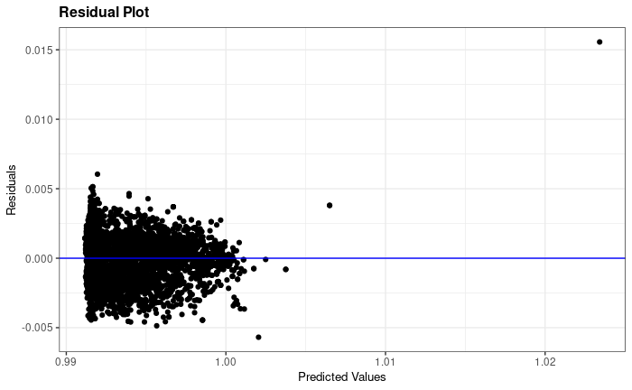

```r
library(ggResidpanel)
resid_panel(reg, plots="resid")
```

Let us check the standard deviation of the dependent variable to have an idea on the scale of the values:

```r
sd(winequality$density)
```

```
[1] 0.002990907
```

As compared to the standard deviation, some of the residuals in the plot are not very small. However, the residual are more or less random, even if not perfectly so. We can say that the fit is not perfectly linear, but still reasonable, as also confirmed by the $R^2$ value of about $0.7$ that we obtained from the summary before.